# Ether Volatility Analysis

Zack Pollak & Matthew McCarthy

November 12, 2017

# Volatility

Volatility is a good series to forecast due mean-reversion and clustering. There are also plentiful well-established models for forecasting volatility. We will begin with these and probably extend via ML. Hypothesis is that we will be able to forecast volatility well and can use these results as feature variables in ML algos. Hope is to dig into relationship between volatility and return - if there is a strong enough correlation between the two, we can forecast big swings in volatility and then place positions accordingly (clearly taking into account relationship to returns). We basically want to capture largest returns possible with as few trades possible. Driving idea here is to place trade just before a volatility spike that is indicative of positive return spike. Forecasting the volatility spike should be the easy part, the heavy lifting will be finding if the volatility spike will result in a positive return spike or a negative return spike.

### R Packages

Here is a list of the required packages used in this (example) strategy, keep in mind all dependencies are loaded as well via the `library()` call: dygraphs = R interface to open source JavaScript charting library  
quantmod = Quantitative Financial Modelling Framework  
rugarch = Univariate GARCH modelling package

```r
### Setwd() and load packages
setwd('~/desktop/crypto')
library(quantmod)
library(dygraphs)
library(rugarch)
```

### Import and Clean the Data

This Ethereum (ETHUSD) data was scraped from CoinMarketCap and came in form of OHLC-V-MC (Open, High, Low, Close, Volume, Market Cap). The data ranges from $2015-08-08$ to $2017-10-14$.

```r
### Import and Clean Data
eth = read.delim('eth_tsv.tsv', header = T)
# Flip the dataset, beginning to end
eth = eth[nrow(eth):1,]
# Remove first row, market cap is blank
eth = eth[-1,]
# Remove commas
eth$Volume = gsub(',', '', eth$Volume)
eth$Market.Cap = gsub(',', '', eth$Market.Cap)
# Convert dates for time-series
dates = gsub(' ', '', gsub(', ', '', eth$Date))
dates = as.Date(dates, '%B%d%Y')
eth$Date = dates
# Convert to xts
eth = xts(eth, as.Date(eth$Date, format='%Y%m%d%'))
# Delete the date column
eth = eth[,-1]
```

### Transformations

Let’s run some transformations on the data. Start with generating daily log close-to-close returns. We’ll also create lagged closes and lagged returns for 1-10 days for future modeling purposes.

Please note that NA’s are introduced due to computing returns and lagged columns. After cleansing the data frame, we are left with data raning from $2015-11-06$ to $2017-10-14$.

```r
### Transformations
# Daily Continuous (Log) Returns
storage.mode(eth) = 'numeric'
eth$Ret = ROC(Cl(eth), type = 'continuous')
# Remove first row, NA introduced by ROC()
eth = eth[-1,]
# Lagged Close
lagged_close = Lag(eth$Close, 1:10)
names(lagged_close) = c('Close.1', 'Close.2', 'Close.3', 'Close.4', 'Close.5',
                      'Close.6', 'Close.7', 'Close.8', 'Close.9', 'Close.10')
eth = merge(eth, lagged_close)
# Lagged Returns
lagged_ret = Lag(eth$Ret, 1:10)
names(lagged_ret) = c('Ret.1', 'Ret.2', 'Ret.3', 'Ret.4', 'Ret.5',
                      'Ret.6', 'Ret.7', 'Ret.8', 'Ret.9', 'Ret.10')
eth = merge(eth, lagged_ret)
# Rolling Volatility
eth$Vol.7 = rollapplyr(eth$Ret, 7, sd)
eth$Vol.14 = rollapplyr(eth$Ret, 14, sd)
eth$Vol.30 = rollapplyr(eth$Ret, 30, sd)
eth$Vol.60 = rollapplyr(eth$Ret, 60, sd)
eth$Vol.90 = rollapplyr(eth$Ret, 90, sd)
eth = na.omit(eth)
```

### Exploratory Data Analysis

Let’s do some exploratory data analysis and checkout some visualizations of the data that will likely feature prominently in our models.

```r
# Exploratory Data Analysis
close = eth$Close
rets = eth$Ret
vol7_vol14 = eth[,c('Vol.7', 'Vol.14')]
vol7 = eth$Vol.7
```

##### Daily Returns

```r
dygraph(rets, main = 'Daily Log Returns') %>%
  dyRangeSelector()
```

[interactive chart not shown]

##### Daily Close

```r
dygraph(close, main = 'Daily Close') %>%
  dyRangeSelector()
```

[interactive chart not shown]

##### 7-Day/14-Day Volatility Crossovers

```r
dygraph(vol7_vol14, main = 'Vol7-Vol14 Crossover') %>%
  dyRangeSelector()
```

[interactive chart not shown]

##### 7-Day Volatility

```r
dygraph(vol7, main = '7 Day Volatility') %>%
  dyRangeSelector()
```

[interactive chart not shown]

### Models

Split the data into train and test samples, we won’t necisarily be using this for our autoregressive models, however, it will come in handy for ML techniques.

```r
train_size = floor((2/3)*nrow(eth))
test_start = train_size + 1
train = eth[c(1:train_size),]
test = eth[c(test_start:nrow(eth)), ]
```

##### GARCH(1,1)

We’ll start out with a basic Garch(1,1) model. GARCH = Generalized Autoregressive Conditional Heteroskedasticity.

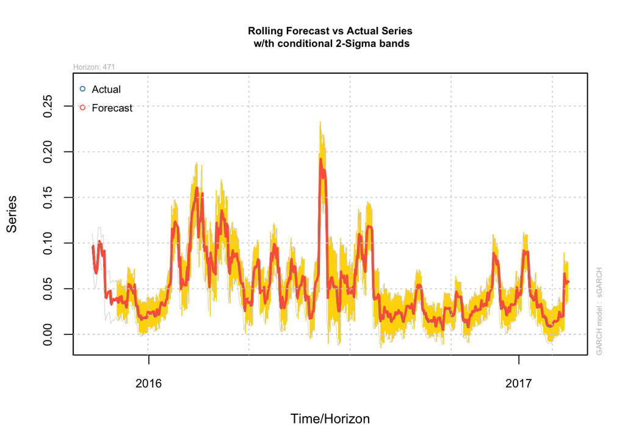

```r
# GARCH(1,1)
library(rugarch)
set.seed(222)
vol7_train = train$Vol.7
spec = ugarchspec()
fit = ugarchfit(spec, vol7_train)
spec = getspec(fit)
setfixed(spec) = as.list(coef(fit))
forecast = ugarchforecast(spec, n.ahead = 1, n.roll = length(vol7_train)-1,
                          data = vol7_train, out.sample = length(vol7_train)-1)
preds = fitted(forecast)
plot(forecast, which = 2)
```

###### References

1. “Volatility Trading” by Euan Sinclair"